# DATA607 Project 4

Farhod Ibragimov

2025-05-03

## Project Description

In this project, I work on classifying news articles as either fake or true using logistic regression. I use small datasets from GitHub, clean and prepare the text, convert it to TF-IDF format, and train the model using tidymodels. I also tune the penalty parameter using cross-validation and evaluate the model using accuracy, AUC, confusion matrix, and ROC curve. Finally, I show the most informative words that help the model decide between fake and true news. This is a full machine learning pipeline, from loading the data to interpreting the results.

## Libraries

We load all required libraries for modeling, text processing, and evaluation.

```r
library(tidymodels)
library(textrecipes)
library(tidytext)
library(yardstick)
library(stringr)
```

## Load Datasets

We read fake and true news CSV files from GitHub.

```r
url_fake_small <- "https://raw.githubusercontent.com/farhodibr/CUNY-SPS-MSDS/refs/heads/main/DATA607/PROJECT4/Fake_small.csv"
url_true_small <- "https://raw.githubusercontent.com/farhodibr/CUNY-SPS-MSDS/refs/heads/main/DATA607/PROJECT4/True_small.csv"

# Read CSVs into data frames
df_fake <- as.data.frame(read.csv(url_fake_small))
df_true <- as.data.frame(read.csv(url_true_small))
```

## Show Example Rows

View the first row of each dataset to understand the structure.

```r
df_fake |> head(1)
```

```
##                                                                                                                 title
## 1 HOW GORSUCH Will Have Immediate Effect On Historic 2nd Amendment Decision And These Significant Controversial Cases
##                                                                                                                                                                                                                                                                                                          …
## 1 Neil M. Gorsuch joins the Supreme Court just in time to cast potentially significant votes in cases that pit religious liberty against gay rights, test limits on funding for church schools and challenge California s restrictions on carrying a concealed gun in public.Such issues arise either in …
##     subject        date
## 1 left-news Apr 9, 2017
```

```r
df_true |> head(1)
```

```
##                                                                title
## 1 Bid to 'fix' Iran nuclear deal faces uphill climb in U.S. Congress
##                                                                                                                                                                                                                                                                                                          …
## 1 WASHINGTON (Reuters) - President Donald Trump s call for Congress to toughen the Iran nuclear deal faced opposition on Friday from among the ranks of his fellow Republicans as well as from Democrats, narrowing the chances any legislation could pass. As Trump announced that he had chosen not to …
##     subject             date
## 1 worldnews October 13, 2017
```

## Combine and Clean Data

We add labels and join title + text columns. Missing values are handled.

```r
df_fake <- df_fake |> mutate(label = factor("fake"))
df_true <- df_true |> mutate(label = factor("true"))

# Combine and clean
df_combined <- bind_rows(df_fake, df_true) |>
  mutate(
    title = ifelse(is.na(title), "", title),
    text = ifelse(is.na(text), "", text),
    full_text = paste(title, text, sep = " ")
  ) |>
  select(full_text, label) |>
  mutate(doc_id = row_number()) |>
  select(doc_id, full_text, label)
```

## Shuffle and View Sample

Shuffle rows and preview 10 examples.

```r
set.seed(123)
df_combined <- df_combined |> slice_sample(prop = 1)
df_combined |> head(10)
```

```
##    doc_id
## 1    2463
## 2    2511
## 3    2227
## 4     526
## 5     195
## 6    2986
## 7    1842
## 8    1142
## 9    3371
## 10   1253
##                                                                                                                                                                                                                                                                                                          …
## 1  'Rage against the machine': U.S. voters reject a 'rigged' system (This November 9th story has been refiled to clarify that Keyes comment in 3rd paragraph from end was said in jest) By Andy Sullivan and Michelle Conlin WASHINGTON (Reuters) - In a bitterly divisive presidential election, at leas…
## 2                                                                                                                                                                                                                                                                                                        …
## 3                                                                                                                                                                                                                                                                                                        …
```

[output cut: 18 more lines]

## Train-Test Split

We split the data (80% train / 20% test), stratified by label.

```r
df_model <- df_combined |> select(full_text, label)

data_split <- initial_split(df_model, prop = 0.8, strata = label)
train_data <- training(data_split)
test_data <- testing(data_split)
```

## Text Preprocessing Recipe

Create a recipe for tokenizing, removing stopwords, filtering vocabulary, and calculating TF-IDF.

```r
text_rec <- recipe(label ~ full_text, data = train_data) |>
  step_tokenize(full_text) |>
  step_stopwords(full_text) |>
  step_tokenfilter(full_text, max_tokens = 5000) |>
  step_tfidf(full_text)
```

## Define Model and Workflow

Set up a logistic regression model with L1 regularization (lasso) and connect it to the recipe.

```r
log_model <- logistic_reg(penalty = tune(), mixture = 1) |>
  set_engine("glmnet") |>
  set_mode("classification")

log_wflow <- workflow() |>
  add_model(log_model) |>
  add_recipe(text_rec)
```

## Cross-Validation Setup

Use 5-fold cross-validation and create a small grid of penalty values for tuning.

```r
set.seed(321)
folds <- vfold_cv(train_data, v = 5, strata = label)
grid <- tibble(penalty = c(0.01, 0.1))

metrics_to_use <- yardstick::metric_set(
  yardstick::accuracy,
  yardstick::roc_auc
)
```

## Tune the Model

Use tune_grid to evaluate model performance across the grid.

```r
tuned_res <- tune_grid(
  log_wflow,
  resamples = folds,
  grid = grid,
  metrics = metrics_to_use
)
```

## Finalize Model

Pick the best model and refit it on the full training set.

```r
best_model <- select_best(tuned_res, metric = "accuracy")
final_wflow <- finalize_workflow(log_wflow, best_model)
final_fit <- fit(final_wflow, data = train_data)
```

## Evaluate on Test Data

Predict test set labels, calculate metrics, and show confusion matrix.

```r
results <- predict(final_fit, test_data, type = "prob") |>
  bind_cols(predict(final_fit, test_data)) |>
  bind_cols(test_data)

metrics(results, truth = label, estimate = .pred_class)
```

```
## # A tibble: 2 × 3
##   .metric  .estimator .estimate
##   <chr>    <chr>          <dbl>
## 1 accuracy binary         0.986
## 2 kap      binary         0.972
```

```r
conf_mat(results, truth = label, estimate = .pred_class)
```

```
##           Truth
## Prediction fake true
##       fake  394    5
##       true    6  395
```

## Visualize Tuning Performance

Show how accuracy changes across penalty values.

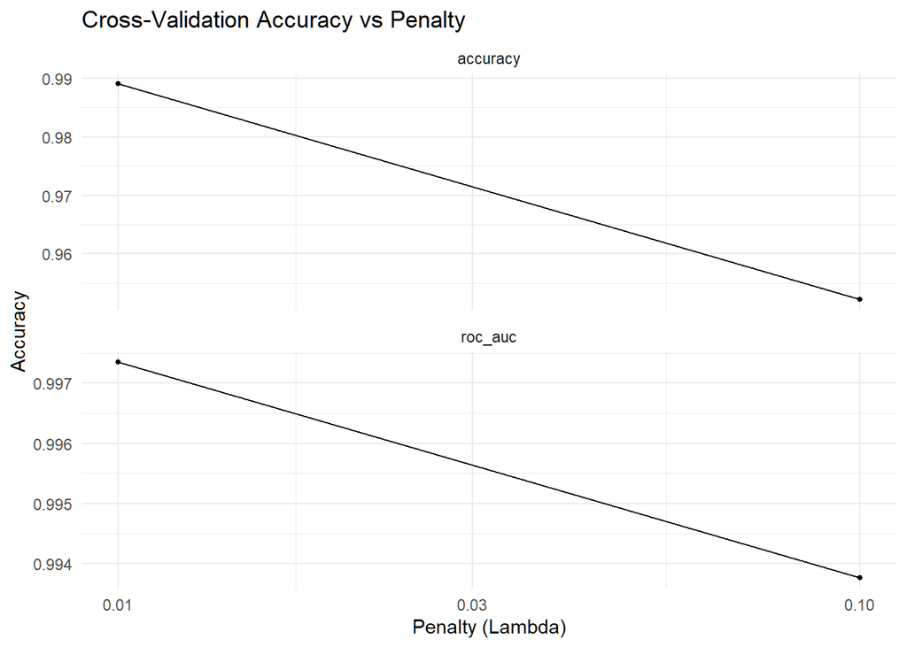

```r
autoplot(tuned_res) +
  labs(
    title = "Cross-Validation Accuracy vs Penalty",
    x = "Penalty (Lambda)",
    y = "Accuracy"
  ) +
  theme_minimal()
```

## Confusion Matrix Heatmap

Visual plot of confusion matrix for easier interpretation.

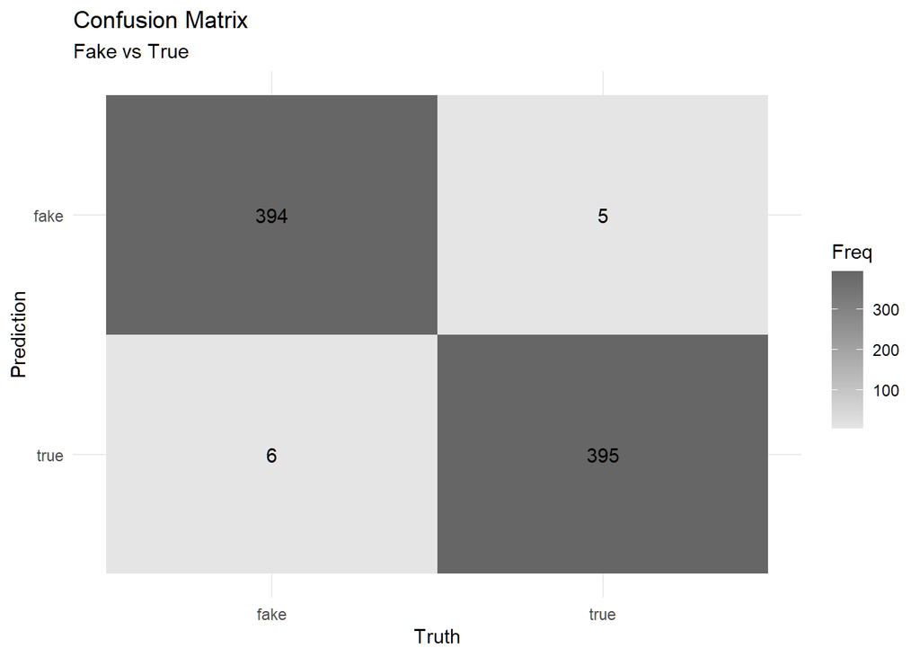

```r
predict(final_fit, test_data) |>
  bind_cols(test_data) |>
  conf_mat(truth = label, estimate = .pred_class) |>
  autoplot(type = "heatmap") +
  labs(title = "Confusion Matrix", subtitle = "Fake vs True") +
  theme_minimal()
```

## ROC Curve

Show trade-off between true positive and false positive rate.

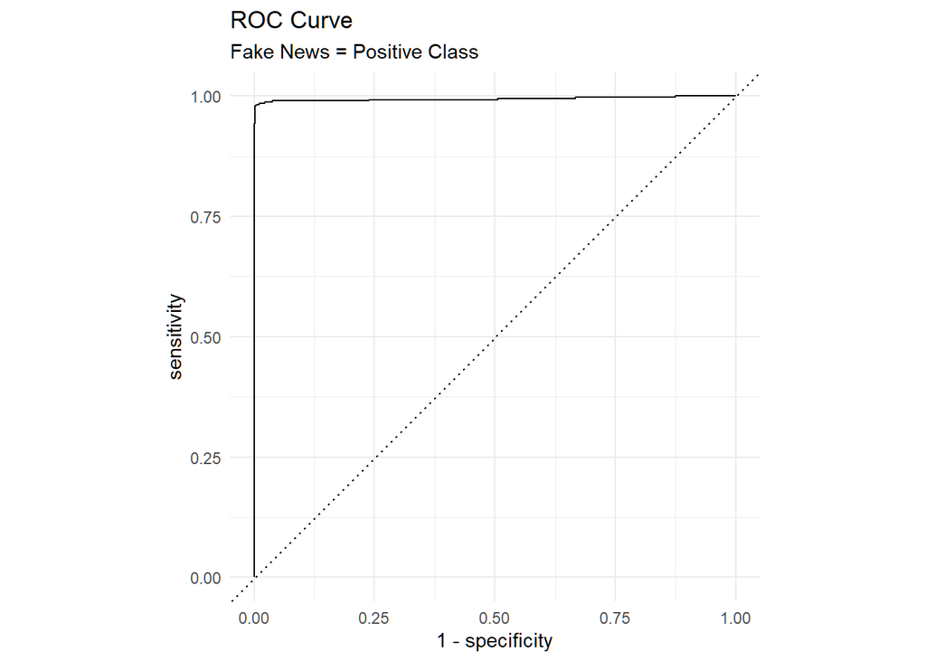

```r
roc_curve(results, truth = label, .pred_fake) |>
  autoplot() +
  labs(title = "ROC Curve", subtitle = "Fake News = Positive Class") +
  theme_minimal()
```

## Top TF-IDF Words by Label

Highlight the most informative words by label using TF-IDF.

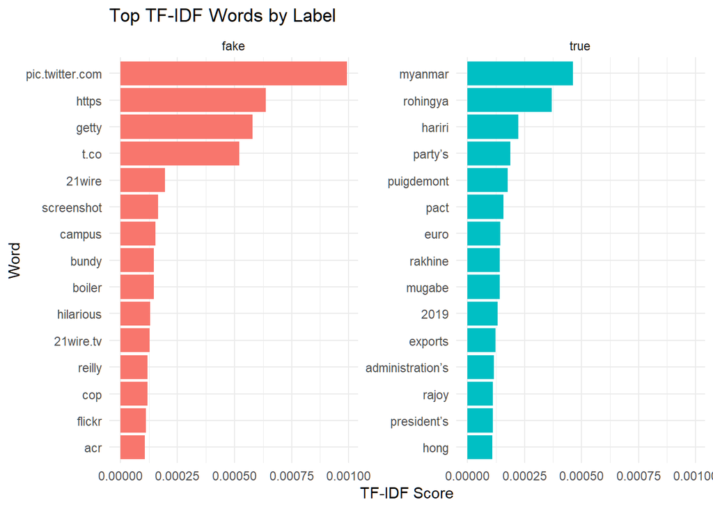

```r
tidy_tokens <- train_data |>
  unnest_tokens(word, full_text) |>
  anti_join(stop_words, by = "word") |>
  filter(str_length(word) > 2) |>
  count(label, word, sort = TRUE) |>
  bind_tf_idf(term = word, document = label, n = n)

top_words <- tidy_tokens |>
  group_by(label) |>
  slice_max(tf_idf, n = 15, with_ties = FALSE) |>
  ungroup()

ggplot(top_words, aes(x = tf_idf, y = reorder_within(word, tf_idf, label))) +
  geom_col(aes(fill = label), show.legend = FALSE) +
  facet_wrap(~ label, scales = "free_y") +
  scale_y_reordered() +
  labs(title = "Top TF-IDF Words by Label", x = "TF-IDF Score", y = "Word") +
  theme_minimal()
```

## Conclusion

- We trained a logistic regression model to classify news as fake or true.
- TF-IDF was used to turn text into numeric features.
- We evaluated the model using accuracy, AUC, ROC curve, and top word plots.
- Next step: try more models like Random Forest or XGBoost.